# Adhoc Lab

### Birla Institute of applied sciences

Submitted By:

1. Karan Joshi (190050101033)
2. Tanmaya Singh (190050101064)
3. Saurav Kumar (190050101051)
4. Riyaz Ahmad (190050101049)
5. Aayush Kumar (190050101001)

Submitted To:

## Dr. Sandesh Tripathi

(HOD-CSE)

## Introduction

- In this LAB we have conducted data visualization on the data which consists of different **Signal Strength** and **ASU's** reading taken at various places within BIAS campus and througout the Bhimtal Lake
- The devices used were **Nothing Phone(1){Latest tech}** and **Redmi Note 9{Older tech}**, And the sim used was **Airtel 4g** for both devices
- First we import the 2 CSV's files containing data within BIAS campus and within the Bhimtal Lake.
- Then we installed the following libraries :
  1. matplotlib and seaborn to visualize our data
  2. pandas to clean and process data
- After that we do some data cleaning using pandas , for eg:
  1. Renaming the coloumn name so that we can process them.
  2. Removing the decimal values so that we can plot graph out of them .
  3. Removing NaN and Null values to remove discrepancy.
- After that We have performed the data visualization.

## Procedure

Use the "Run" button to execute the code.

```python
pip install matplotlib
```

```python
from matplotlib import pyplot as plt
```

```python
import pandas as pd
import seaborn as sns
```

```python
spreadsheet = pd.read_csv("ADHOC.csv")
spreadsheet2 = pd.read_csv("ADHOC2.csv")
```

```python
spreadsheet.head()
```

|  | Location | Db Level (in ) | asu\t | Uplink Frequency(in ) | Downlink Frequency(in ) |
| --- | --- | --- | --- | --- | --- |
| 0 | classroom | -79 | 63 | 15000 | 30000 |
| 1 | Terrace | -90 | 65 | 15000 | 30000 |
| 2 | Goal post | -88 | 55 | 15000 | 30000 |
| 3 | Parking old buliding | -85 | 57 | 15000 | 30000 |
| 4 | Entance Old Buliding | -88 | 53 | 15000 | 30000 |

```python
spreadsheet2.head()
```

|  | Location | dBLevel | asu | Uplink Frequency(in kbps)\t | Downlink Frequency(in kbps) |
| --- | --- | --- | --- | --- | --- |
| 0 | Main Gate | -94 | 46 | 15000 | 30000 |
| 1 | Petrol Pump | -93 | 47 | 21932 | 26864 |
| 2 | Blockroad | -91 | 49 | 21932 | 26864 |
| 3 | Tikonia | -84 | 56 | 21932 | 26864 |
| 4 | Back Tikonia Bypass | -93 | 47 | 21932 | 26864 |

```python
spreadsheet.rename(
    columns=({ 'asu\t': 'asu','Db Level (in )':'dBLevel'}),
    inplace=True,
)
```

```python
spreadsheet.head()
```

|  | Location | dBLevel | asu | Uplink Frequency(in ) | Downlink Frequency(in ) |
| --- | --- | --- | --- | --- | --- |
| 0 | classroom | -79 | 63 | 15000 | 30000 |
| 1 | Terrace | -90 | 65 | 15000 | 30000 |
| 2 | Goal post | -88 | 55 | 15000 | 30000 |
| 3 | Parking old buliding | -85 | 57 | 15000 | 30000 |
| 4 | Entance Old Buliding | -88 | 53 | 15000 | 30000 |

```python
spreadsheet2
```

|  | Location | dBLevel | asu | Uplink Frequency(in kbps)\t | Downlink Frequency(in kbps) |
| --- | --- | --- | --- | --- | --- |
| 0 | Main Gate | -94 | 46 | 15000 | 30000 |
| 1 | Petrol Pump | -93 | 47 | 21932 | 26864 |
| 2 | Blockroad | -91 | 49 | 21932 | 26864 |
| 3 | Tikonia | -84 | 56 | 21932 | 26864 |
| 4 | Back Tikonia Bypass | -93 | 47 | 21932 | 26864 |
| 5 | The Fern Hillside Resort | -93 | 47 | 21932 | 26864 |
| 6 | Beside Lake | -99 | 41 | 21932 | 26864 |
| 7 | Town Pride Home Stay | -90 | 50 | 21932 | 26864 |
| 8 | Pan Vilas Resort | -85 | 55 | 21932 | 26864 |
| 9 | Maulana Lake Retreat | -85 | 55 | 21932 | 26864 |
| 10 | Pant Park | -92 | 48 | 21932 | 26864 |
| 11 | Maulana Lake Retreat | -83 | 57 | 21932 | 26864 |
| 12 | Neelesh Inn | -82 | 58 | 21932 | 26864 |
| 13 | End OF Monolith | -108 | 32 | 13548 | 31695 |
| 14 | Nagar Palika Bhimtal | -88 | 52 | 21932 | 26864 |
| 15 | Dam Arc | -86 | 54 | 21932 | 26864 |
| 16 | Dam | -89 | 51 | 21932 | 26864 |
| 17 | Daat Parking Lot | -99 | 41 | 13548 | 31695 |
| 18 | Kainchula Devi Mandir | -91 | 49 | 21932 | 26864 |
| 19 | Mount Alvern School | -91 | 49 | 21932 | 26864 |

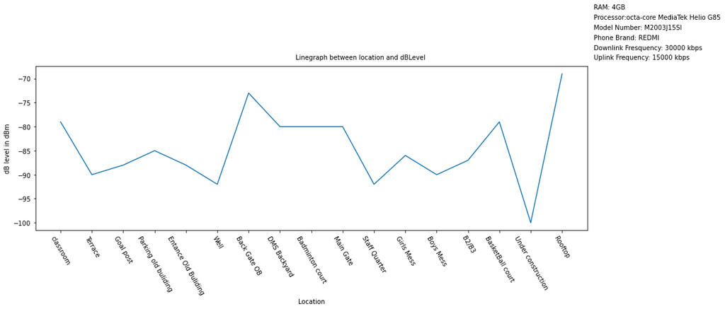

```python
plt.rcParams["figure.figsize"] = [13.00, 5.50]
plt.rcParams["figure.autolayout"] = True
columns = ["Location", "dBLevel"]
plt.xticks(rotation = 300)
plt.ylabel("dB level in dBm")
plt.xlabel("Location")
plt.figtext(1, 1, "Uplink Frequency: 15000 kbps")
plt.figtext(1, 1.04, "Downlink Fresquency: 30000 kbps")
plt.figtext(0.5, 1, "Linegraph between location and dBLevel")
plt.figtext(1, 1.08, "Phone Brand: REDMI")
plt.figtext(1, 1.12, "Model Number: M2003J15SI")
plt.figtext(1, 1.16, "Processor:octa-core MediaTek Helio G85")
plt.figtext(1, 1.20, "RAM: 4GB")
plt.plot(spreadsheet.Location, spreadsheet.dBLevel)
```